# Codeathon 2: UVA Landmark Image Recognition

**CS 4774 — Machine Learning**  
**Bill Brinkley**

[figure not shown]

This notebook is an updated version of my submission for the second Codeathon of my Fall 2022 undergraduate machine learning class. Starter code was provided to facilitate data processing, and has been adapted where necessary. The goal of the project is given below as originally stated:

> *"The UVA Grounds is known for its Jeffersonian architecture and place in U.S. history as a model for college and university campuses throughout the country. Throughout its history, the University of Virginia has won praises for its unique Jeffersonian architecture.*

> *In this codeathon, you will attempt to build an image recognition system to classify different buildings/landmarks on Grounds."*

## Local Environment Setup (Conda)

To run this notebook locally, we recommend using a Conda environment with the following configuration:

```
conda create -n uva-codeathon python=3.9
conda activate uva-codeathon

pip install numpy matplotlib scikit-learn tensorflow==2.13 tqdm jupyter
```

## Loading and Preparing the Dataset

The full UVA landmark dataset is over 37GB, with more than 13,000 images across 18 classes. Since that’s a bit too large to work with easily, we were provided a subset that’s been resized and compressed to around 379MB.

All images in this subset have been resized to 224×224 to match the input size expected by most pretrained models, which we’ll use later for transfer learning.

```
dataset.zip already exists, skipping download.
Extracting dataset...
Extraction complete.
```

```
Found 14286 files belonging to 18 classes.
Using 11429 files for training.
Found 14286 files belonging to 18 classes.
Using 2857 files for validation.
```

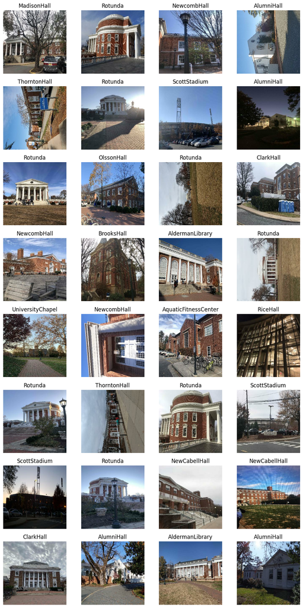

## Custom CNN Architecture

Below is an improved version of my original model, which was loosely based on AlexNet. The earlier architecture was too shallow and lacked regularization, which led to limited performance and early overfitting (never surpassing 70% accuracy).

This revised network stacks multiple convolutional layers per block, with increasing filter sizes and batch normalization to stabilize learning. Max pooling is applied after each block to reduce spatial dimensions, and dropout is included to help prevent overfitting. The model ends with global average pooling and a dense head as opposed to my previous more traditional flatten layer.

### Summary:

- **Number of layers**: 26 (including conv, batch norm, pooling, dropout, and dense layers)
- **Activation functions**: ReLU in all hidden layers, Softmax in the output
- **Regularization**: Dropout and batch normalization after most conv layers
- **Final layer**: Dense with 18 units for UVA building classification
- **Loss function**: `sparse_categorical_crossentropy`
- **Optimizer**: `adam`
- **Metrics**: Accuracy

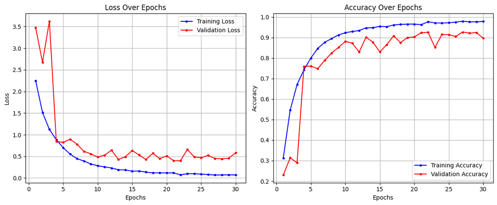

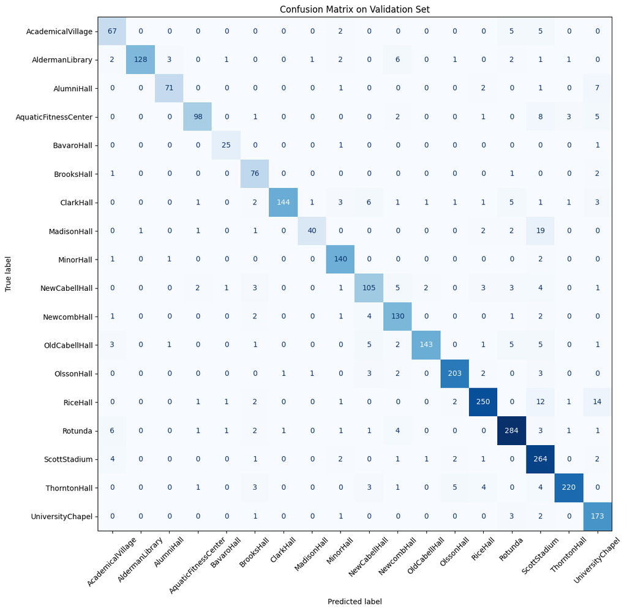

## Transfer Learning with a Pretrained Network

Now that a custom CNN baseline has been established, we turn to transfer learning using pretrained networks. The goal is to leverage models trained on large-scale image datasets (like ImageNet) to extract general features that can be adapted to our specific 18-class UVA building classification task.

As required, I avoided the provided options like `Xception`, `MobileNet`, and `EfficientNetB6`. Instead, I experimented with two pretrained architectures:

- **VGG16**
- **ResNet101**

After minimal preliminary testing, I proceeded with **ResNet101**.

Rather than using a strict two-phase training schedule, I opted to only unfreeze the top layers of the network (above layer 100), which provided enough flexibility for adaptation while avoiding overfitting. Deeper unfreezing was attempted but led to instability or poor convergence, likely due to the smaller dataset size relative to the model’s capacity.

The final model consists of:

- The ResNet101 base (frozen below layer 100)
- A `GlobalAveragePooling2D` layer
- A final `Dense(18, softmax)` classification head

```
Downloading data from https://storage.googleapis.com/tensorflow/keras-applications/resnet/resnet101_weights_tf_dim_ordering_tf_kernels_notop.h5
```

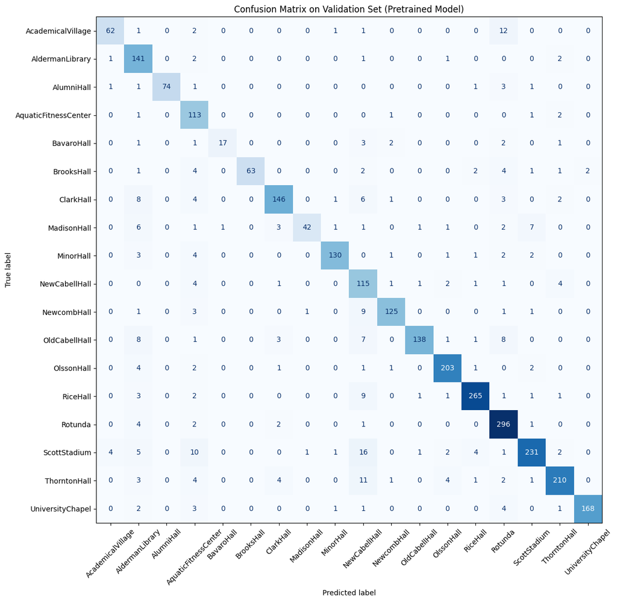

## Results Section

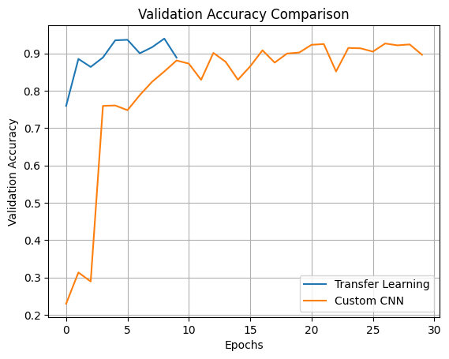

```
Custom CNN:
Train Accuracy: 0.9789, Train Loss: 0.0699
Val Accuracy:   0.8964, Val Loss:   0.5824

Transfer Learning (ResNet101):
Train Accuracy: 0.9952, Train Loss: 0.0174
Val Accuracy:   0.8887, Val Loss:   0.6279
```

## Final Results and Model Comparison

After completing training for both models, we compare their overall performance and training efficiency:

### Custom CNN (30 epochs, ~305 minutes)

- **Final Train Accuracy:** 97.9%
- **Final Val Accuracy:** 89.6%
- **Final Val Loss:** 0.582
- **Peak Val Accuracy (during training):** 92.65%

### Transfer Learning (ResNet101, 10 epochs, ~190 minutes)

- **Final Train Accuracy:** 99.5%
- **Final Val Accuracy:** 88.9%
- **Final Val Loss:** 0.628
- **Peak Val Accuracy (during training):** 93.96%

### Summary

- The **custom CNN** performed slightly better in terms of final validation accuracy, although the **transfer learning model peaked higher** (93.96%) at an earlier epoch.
- Training time was significantly shorter for the transfer model (190 min vs. 305 min), despite having a deeper architecture, due to the smaller number of epochs and pre-trained feature extraction.
- Given more epochs and regularization tuning, the transfer model could likely surpass the custom CNN consistently, but under these conditions, the **custom model generalizes slightly better** by the end of training.